# Introducción al clustering en R

K-means, clustering jerárquico, evaluación de clusters, PCA antes de clustering, pruebas estadísticas y predicción de membresía

Minería de Datos

2026-06-16

# 1. Objetivos de aprendizaje

En este notebook aprenderemos a:

1. Preparar un conjunto de datos para análisis de clustering.
2. Aplicar **k-means** y **clustering jerárquico**.
3. Evaluar el **número óptimo de clusters** usando el método del codo, silhouette y gap statistic.
4. Realizar clustering **después de PCA** y compararlo con clustering sobre las variables originales escaladas.
5. Describir, visualizar e interpretar clusters.
6. Aplicar pruebas estadísticas para comparar variables entre clusters.
7. Entrenar modelos de regresión para **predecir la membresía a clusters**.

Usaremos el dataset `iris`, que viene incluido en R. Es un dataset simple, limpio y disponible en cualquier instalación de R. La variable `Species` se usará solo como referencia externa después del clustering, no para construir los clusters.

# 2. Instalar y cargar paquetes

```r
packages <- c(
  "tidyverse",
  "cluster",
  "factoextra",
  "broom",
  "nnet"
)

to_install <- packages[!sapply(packages, requireNamespace, quietly = TRUE)]

if (length(to_install) > 0) {
  install.packages(to_install, repos = "https://cloud.r-project.org")
}

library(tidyverse)
library(cluster)
library(factoextra)
library(broom)
library(nnet)
```

# 3. Introducción conceptual

El **clustering** es una técnica de **aprendizaje no supervisado**. Esto significa que no usamos una variable respuesta ni una etiqueta conocida para entrenar el modelo. En cambio, el algoritmo intenta descubrir grupos de observaciones que sean similares entre sí.

Un flujo típico de clustering es:

1. Seleccionar variables relevantes.
2. Escalar las variables numéricas.
3. Elegir una métrica de distancia.
4. Elegir un algoritmo de clustering.
5. Decidir el número de clusters.
6. Interpretar los clusters encontrados.
7. Opcionalmente, usar las etiquetas de cluster como variable respuesta en un modelo predictivo.

Idea importante: el clustering es exploratorio. Los clusters no son automáticamente “grupos biológicos reales”, “segmentos reales de clientes” o “subtipos clínicos reales”. Deben ser interpretados y validados.

# 4. Cargar e inspeccionar los datos

```r
data("iris")

iris_tbl <- as_tibble(iris)

glimpse(iris_tbl)
```

```
## Rows: 150
## Columns: 5
## $ Sepal.Length <dbl> 5.1, 4.9, 4.7, 4.6, 5.0, 5.4, 4.6, 5.0, 4.4, 4.9, 5.4, 4.…
## $ Sepal.Width  <dbl> 3.5, 3.0, 3.2, 3.1, 3.6, 3.9, 3.4, 3.4, 2.9, 3.1, 3.7, 3.…
## $ Petal.Length <dbl> 1.4, 1.4, 1.3, 1.5, 1.4, 1.7, 1.4, 1.5, 1.4, 1.5, 1.5, 1.…
## $ Petal.Width  <dbl> 0.2, 0.2, 0.2, 0.2, 0.2, 0.4, 0.3, 0.2, 0.2, 0.1, 0.2, 0.…
## $ Species      <fct> setosa, setosa, setosa, setosa, setosa, setosa, setosa, s…
```

```r
summary(iris_tbl)
```

```
##   Sepal.Length    Sepal.Width     Petal.Length    Petal.Width
##  Min.   :4.300   Min.   :2.000   Min.   :1.000   Min.   :0.100
##  1st Qu.:5.100   1st Qu.:2.800   1st Qu.:1.600   1st Qu.:0.300
##  Median :5.800   Median :3.000   Median :4.350   Median :1.300
##  Mean   :5.843   Mean   :3.057   Mean   :3.758   Mean   :1.199
##  3rd Qu.:6.400   3rd Qu.:3.300   3rd Qu.:5.100   3rd Qu.:1.800
##  Max.   :7.900   Max.   :4.400   Max.   :6.900   Max.   :2.500
##        Species
##  setosa    :50
##  versicolor:50
##  virginica :50
##
##
##
```

El dataset contiene cuatro variables numéricas:

- `Sepal.Length`
- `Sepal.Width`
- `Petal.Length`
- `Petal.Width`

Además contiene una etiqueta conocida:

- `Species`

Para construir los clusters usaremos solo las variables numéricas.

```r
iris_num <- iris_tbl %>%
  select(Sepal.Length, Sepal.Width, Petal.Length, Petal.Width)

head(iris_num)
```

| Sepal.Length | Sepal.Width | Petal.Length | Petal.Width |
| --- | --- | --- | --- |
| 5.1 | 3.5 | 1.4 | 0.2 |
| 4.9 | 3.0 | 1.4 | 0.2 |
| 4.7 | 3.2 | 1.3 | 0.2 |
| 4.6 | 3.1 | 1.5 | 0.2 |
| 5.0 | 3.6 | 1.4 | 0.2 |
| 5.4 | 3.9 | 1.7 | 0.4 |

# 5. Visualización exploratoria

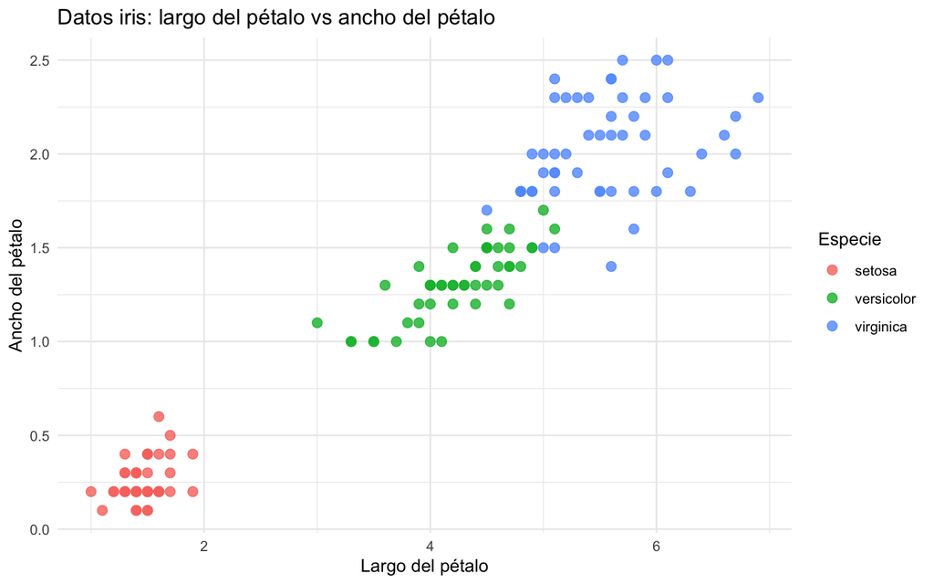

```r
ggplot(iris_tbl, aes(x = Petal.Length, y = Petal.Width, color = Species)) +
  geom_point(size = 2.5, alpha = 0.8) +
  theme_minimal() +
  labs(
    title = "Datos iris: largo del pétalo vs ancho del pétalo",
    x = "Largo del pétalo",
    y = "Ancho del pétalo",
    color = "Especie"
  )
```

Este gráfico usa las etiquetas conocidas de especie solo para exploración. En un problema real de clustering no supervisado, estas etiquetas generalmente no están disponibles.

# 6. Escalamiento de los datos

La mayoría de los métodos de clustering dependen de distancias. Si las variables tienen escalas muy distintas, las variables con rangos numéricos más grandes pueden dominar el resultado.

Por eso, normalmente escalamos las variables numéricas antes de hacer clustering.

```r
iris_scaled <- scale(iris_num)

head(iris_scaled)
```

```
##      Sepal.Length Sepal.Width Petal.Length Petal.Width
## [1,]   -0.8976739  1.01560199    -1.335752   -1.311052
## [2,]   -1.1392005 -0.13153881    -1.335752   -1.311052
## [3,]   -1.3807271  0.32731751    -1.392399   -1.311052
## [4,]   -1.5014904  0.09788935    -1.279104   -1.311052
## [5,]   -1.0184372  1.24503015    -1.335752   -1.311052
## [6,]   -0.5353840  1.93331463    -1.165809   -1.048667
```

Verificamos que las variables escaladas tengan media cercana a 0 y desviación estándar cercana a 1.

```r
apply(iris_scaled, 2, mean)
```

```
##  Sepal.Length   Sepal.Width  Petal.Length   Petal.Width
## -2.318423e-15 -1.684023e-15 -1.577997e-15 -8.829974e-16
```

```r
apply(iris_scaled, 2, sd)
```

```
## Sepal.Length  Sepal.Width Petal.Length  Petal.Width
##            1            1            1            1
```

# 7. Clustering con k-means

K-means intenta dividir las observaciones en `k` clusters minimizando la suma de cuadrados dentro de cada cluster.

Parámetros principales:

- `centers`: número de clusters.
- `nstart`: número de inicializaciones aleatorias. Valores más altos suelen dar resultados más estables.
- `iter.max`: número máximo de iteraciones.

Comenzaremos con `k = 3`.

```r
set.seed(123)

km3 <- kmeans(
  x = iris_scaled,
  centers = 3,
  nstart = 25
)

km3
```

```
## K-means clustering with 3 clusters of sizes 50, 53, 47
##
## Cluster means:
##   Sepal.Length Sepal.Width Petal.Length Petal.Width
## 1  -1.01119138  0.85041372   -1.3006301  -1.2507035
## 2  -0.05005221 -0.88042696    0.3465767   0.2805873
## 3   1.13217737  0.08812645    0.9928284   1.0141287
##
## Clustering vector:
##   [1] 1 1 1 1 1 1 1 1 1 1 1 1 1 1 1 1 1 1 1 1 1 1 1 1 1 1 1 1 1 1 1 1 1 1 1 1 1
##  [38] 1 1 1 1 1 1 1 1 1 1 1 1 1 3 3 3 2 2 2 3 2 2 2 2 2 2 2 2 3 2 2 2 2 3 2 2 2
##  [75] 2 3 3 3 2 2 2 2 2 2 2 3 3 2 2 2 2 2 2 2 2 2 2 2 2 2 3 2 3 3 3 3 2 3 3 3 3
## [112] 3 3 2 2 3 3 3 3 2 3 2 3 2 3 3 2 3 3 3 3 3 3 2 2 3 3 3 2 3 3 3 2 3 3 3 2 3
## [149] 3 2
##
## Within cluster sum of squares by cluster:
## [1] 47.35062 44.08754 47.45019
##  (between_SS / total_SS =  76.7 %)
##
## Available components:
##
## [1] "cluster"      "centers"      "totss"        "withinss"     "tot.withinss"
## [6] "betweenss"    "size"         "iter"         "ifault"
```

Agregamos las etiquetas de cluster al dataset original.

```r
iris_clustered <- iris_tbl %>%
  mutate(cluster_kmeans = factor(km3$cluster))

head(iris_clustered)
```

| Sepal.Length | Sepal.Width | Petal.Length | Petal.Width | Species | cluster_kmeans |
| --- | --- | --- | --- | --- | --- |
| 5.1 | 3.5 | 1.4 | 0.2 | setosa | 1 |
| 4.9 | 3.0 | 1.4 | 0.2 | setosa | 1 |
| 4.7 | 3.2 | 1.3 | 0.2 | setosa | 1 |
| 4.6 | 3.1 | 1.5 | 0.2 | setosa | 1 |
| 5.0 | 3.6 | 1.4 | 0.2 | setosa | 1 |
| 5.4 | 3.9 | 1.7 | 0.4 | setosa | 1 |

Visualizamos los clusters de k-means.

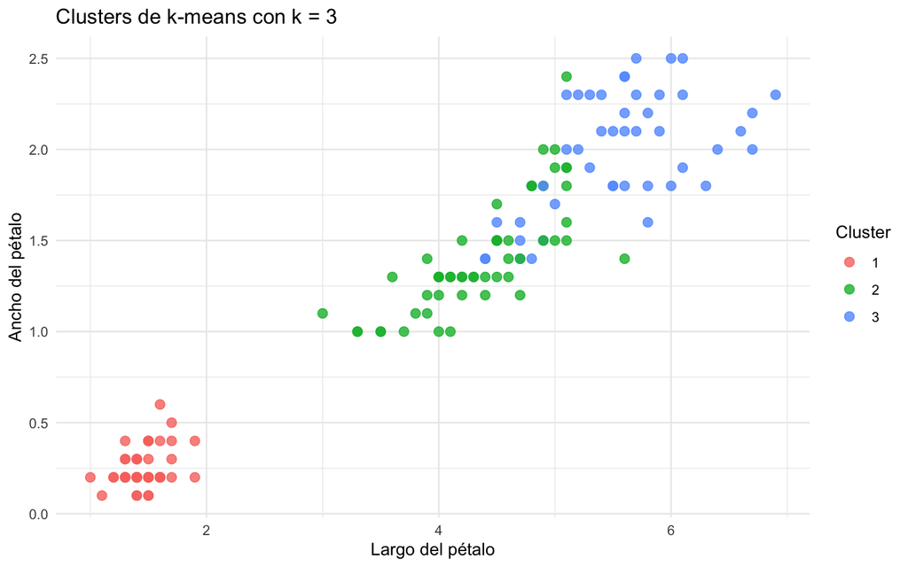

```r
ggplot(iris_clustered, aes(x = Petal.Length, y = Petal.Width, color = cluster_kmeans)) +
  geom_point(size = 2.5, alpha = 0.8) +
  theme_minimal() +
  labs(
    title = "Clusters de k-means con k = 3",
    x = "Largo del pétalo",
    y = "Ancho del pétalo",
    color = "Cluster"
  )
```

# 8. ¿Cómo elegir el número óptimo de clusters?

No existe una respuesta universal. Normalmente combinamos criterios estadísticos, visualización e interpretación del dominio.

Compararemos tres enfoques frecuentes:

1. Método del codo.
2. Ancho promedio de silhouette.
3. Gap statistic.

## 8.1 Método del codo

El método del codo analiza la suma total de cuadrados dentro de los clusters. A medida que `k` aumenta, la variabilidad interna disminuye. Buscamos un punto donde la mejora comienza a hacerse menor.

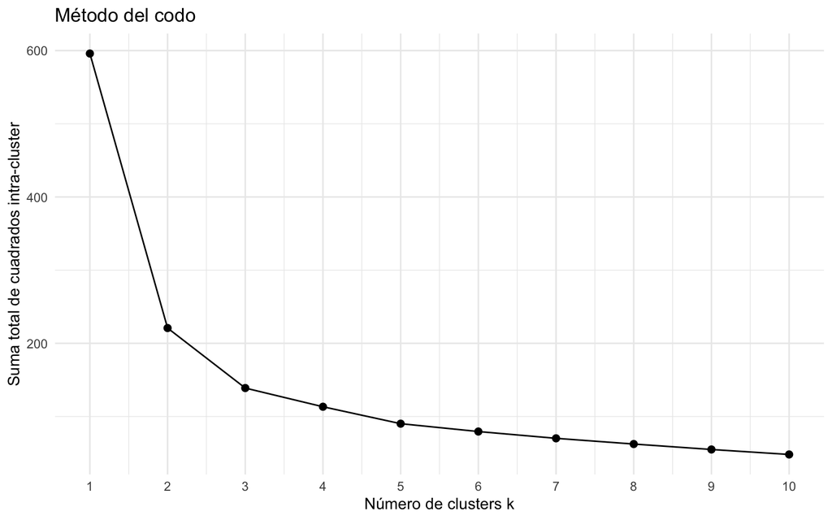

```r
set.seed(123)

wss <- map_dbl(1:10, function(k) {
  kmeans(iris_scaled, centers = k, nstart = 25)$tot.withinss
})

elbow_tbl <- tibble(
  k = 1:10,
  total_within_ss = wss
)

ggplot(elbow_tbl, aes(x = k, y = total_within_ss)) +
  geom_line() +
  geom_point(size = 2) +
  scale_x_continuous(breaks = 1:10) +
  theme_minimal() +
  labs(
    title = "Método del codo",
    x = "Número de clusters k",
    y = "Suma total de cuadrados intra-cluster"
  )
```

Interpretación: el `k` óptimo suele estar cerca del punto donde la curva comienza a aplanarse.

## 8.2 Método de silhouette

El valor de silhouette mide qué tan similar es una observación a su propio cluster comparado con los otros clusters.

- Valores cercanos a 1 sugieren una buena asignación.
- Valores cercanos a 0 sugieren clusters solapados.
- Valores negativos sugieren posible mala asignación.

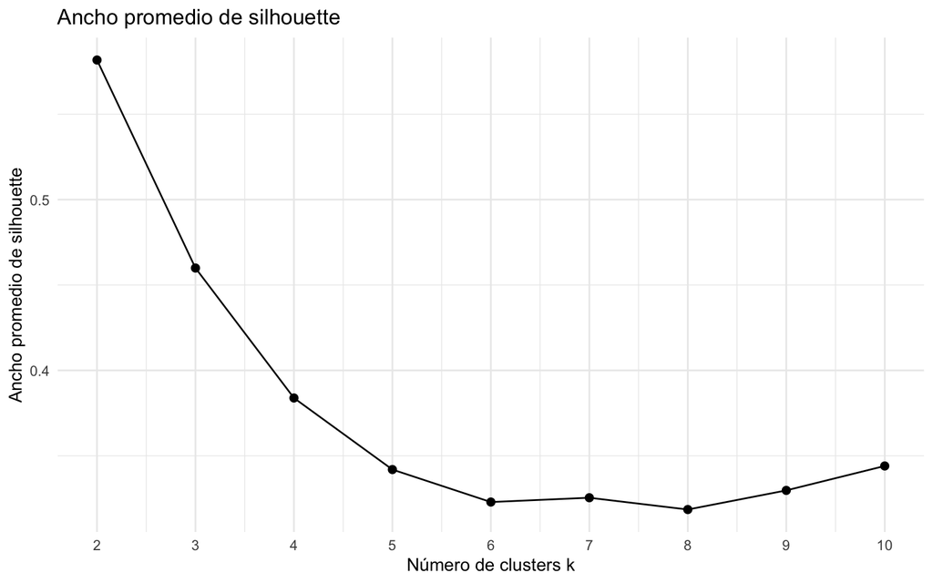

```r
set.seed(123)

sil_width <- map_dbl(2:10, function(k) {
  km <- kmeans(iris_scaled, centers = k, nstart = 25)
  ss <- silhouette(km$cluster, dist(iris_scaled))
  mean(ss[, 3])
})

sil_tbl <- tibble(
  k = 2:10,
  avg_silhouette_width = sil_width
)

ggplot(sil_tbl, aes(x = k, y = avg_silhouette_width)) +
  geom_line() +
  geom_point(size = 2) +
  scale_x_continuous(breaks = 2:10) +
  theme_minimal() +
  labs(
    title = "Ancho promedio de silhouette",
    x = "Número de clusters k",
    y = "Ancho promedio de silhouette"
  )
```

El mejor `k` según este criterio es el que tiene mayor ancho promedio de silhouette.

```r
sil_tbl %>%
  arrange(desc(avg_silhouette_width))
```

| k | avg_silhouette_width |
| --- | --- |
| 2 | 0.5817500 |
| 3 | 0.4599482 |
| 4 | 0.3838509 |
| 10 | 0.3440441 |
| 5 | 0.3419470 |
| 9 | 0.3297370 |
| 7 | 0.3254461 |
| 6 | 0.3229212 |
| 8 | 0.3185370 |

## 8.3 Gap statistic

El gap statistic compara la dispersión observada dentro de los clusters con la dispersión esperada bajo una distribución nula de referencia.

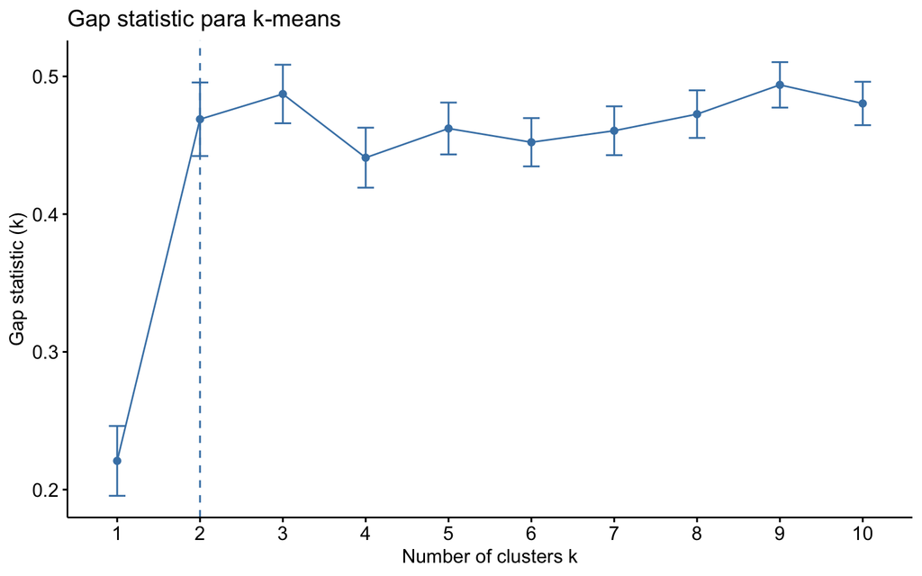

```r
set.seed(123)

gap_kmeans <- clusGap(
  x = iris_scaled,
  FUNcluster = kmeans,
  K.max = 10,
  B = 50,
  nstart = 25
)

fviz_gap_stat(gap_kmeans) +
  labs(title = "Gap statistic para k-means")
```

El gap statistic no siempre coincide con el método del codo o silhouette. En la práctica se combinan varios criterios y se elige una solución que además sea interpretable.

# 9. Modelo final de k-means

Porque `iris` tiene tres especies conocidas, continuaremos con `k = 3`.

```r
set.seed(123)

km_final <- kmeans(
  x = iris_scaled,
  centers = 3,
  nstart = 50
)

iris_km <- iris_tbl %>%
  mutate(cluster_kmeans = factor(km_final$cluster))

iris_km %>%
  count(cluster_kmeans)
```

| cluster_kmeans | n |
| --- | --- |
| 1 | 50 |
| 2 | 53 |
| 3 | 47 |

Comparamos los clusters con las etiquetas conocidas de especie.

```r
table(
  Cluster = iris_km$cluster_kmeans,
  Species = iris_km$Species
)
```

```
##        Species
## Cluster setosa versicolor virginica
##       1     50          0         0
##       2      0         39        14
##       3      0         11        36
```

Esta tabla no se usa para entrenar el modelo de clustering. Solo sirve como una validación externa exploratoria.

# 10. Clustering jerárquico

El clustering jerárquico construye una estructura en forma de árbol llamada dendrograma.

Dos decisiones importantes son:

1. Métrica de distancia: por ejemplo, distancia euclidiana.
2. Método de enlace: por ejemplo, complete, average o Ward.

El método de Ward suele ser una buena opción cuando se usa distancia euclidiana y se esperan clusters relativamente compactos.

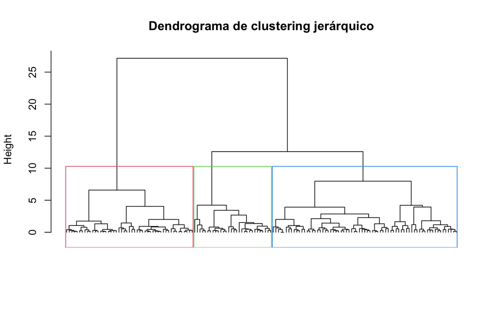

```r
dist_iris <- dist(iris_scaled, method = "euclidean")

hc_ward <- hclust(dist_iris, method = "ward.D2")

plot(
  hc_ward,
  labels = FALSE,
  hang = -1,
  main = "Dendrograma de clustering jerárquico",
  xlab = "",
  sub = ""
)
rect.hclust(hc_ward, k = 3, border = 2:4)
```

Cortamos el dendrograma en tres clusters.

```r
iris_hc <- iris_tbl %>%
  mutate(cluster_hc = factor(cutree(hc_ward, k = 3)))

iris_hc %>%
  count(cluster_hc)
```

| cluster_hc | n |
| --- | --- |
| 1 | 49 |
| 2 | 30 |
| 3 | 71 |

```r
table(
  Cluster = iris_hc$cluster_hc,
  Species = iris_hc$Species
)
```

```
##        Species
## Cluster setosa versicolor virginica
##       1     49          0         0
##       2      1         27         2
##       3      0         23        48
```

Visualizamos los clusters jerárquicos.

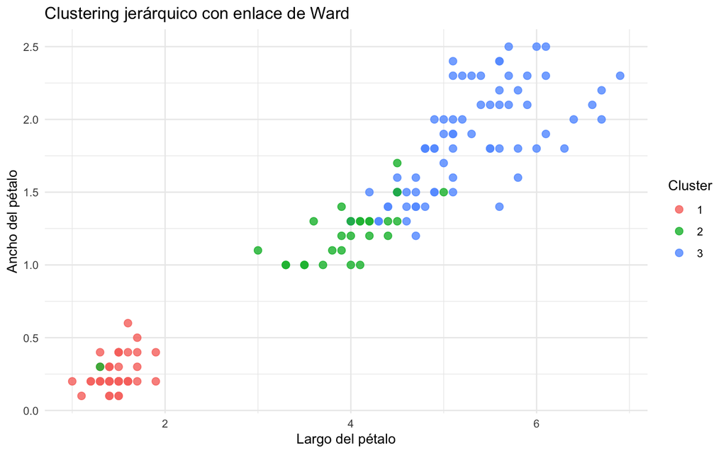

```r
ggplot(iris_hc, aes(x = Petal.Length, y = Petal.Width, color = cluster_hc)) +
  geom_point(size = 2.5, alpha = 0.8) +
  theme_minimal() +
  labs(
    title = "Clustering jerárquico con enlace de Ward",
    x = "Largo del pétalo",
    y = "Ancho del pétalo",
    color = "Cluster"
  )
```

# 11. Clustering después de PCA

PCA puede usarse antes del clustering para:

1. Reducir dimensionalidad.
2. Disminuir redundancia entre variables correlacionadas.
3. Reducir ruido.
4. Visualizar observaciones en un espacio de baja dimensión.

Sin embargo, si se conservan muy pocas componentes, PCA también puede eliminar información útil para el clustering.

## 11.1 Ejecutar PCA

```r
pca_iris <- prcomp(
  iris_scaled,
  center = FALSE,
  scale. = FALSE
)

summary(pca_iris)
```

```
## Importance of components:
##                           PC1    PC2     PC3     PC4
## Standard deviation     1.7084 0.9560 0.38309 0.14393
## Proportion of Variance 0.7296 0.2285 0.03669 0.00518
## Cumulative Proportion  0.7296 0.9581 0.99482 1.00000
```

Como ya escalamos las variables, usamos `center = FALSE` y `scale. = FALSE`.

## 11.2 Scree plot

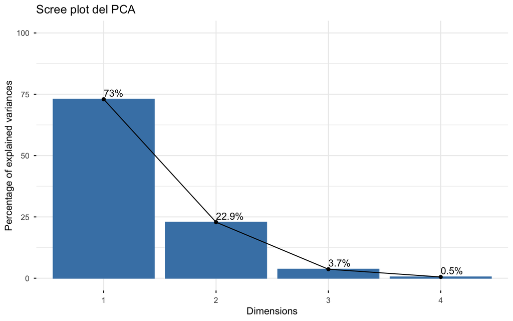

```r
fviz_eig(
  pca_iris,
  addlabels = TRUE,
  ylim = c(0, 100)
) +
  labs(title = "Scree plot del PCA")
```

## 11.3 Scores del PCA

Los **scores** corresponden a la posición de cada observación en el nuevo sistema de coordenadas definido por las componentes principales.

```r
pca_scores <- as_tibble(pca_iris$x) %>%
  mutate(Species = iris_tbl$Species)

head(pca_scores)
```

| PC1 | PC2 | PC3 | PC4 | Species |
| --- | --- | --- | --- | --- |
| -2.257141 | -0.4784238 | 0.12727962 | 0.024087508 | setosa |
| -2.074013 | 0.6718827 | 0.23382552 | 0.102662845 | setosa |
| -2.356335 | 0.3407664 | -0.04405390 | 0.028282305 | setosa |
| -2.291707 | 0.5953999 | -0.09098530 | -0.065735340 | setosa |
| -2.381863 | -0.6446757 | -0.01568565 | -0.035802870 | setosa |
| -2.068701 | -1.4842053 | -0.02687825 | 0.006586116 | setosa |

Visualizamos las primeras dos componentes principales.

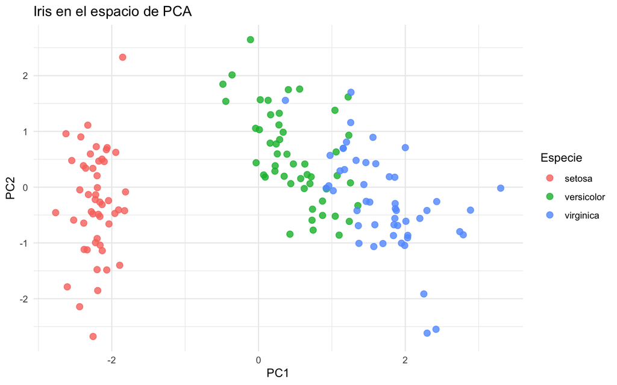

```r
ggplot(pca_scores, aes(x = PC1, y = PC2, color = Species)) +
  geom_point(size = 2.5, alpha = 0.8) +
  theme_minimal() +
  labs(
    title = "Iris en el espacio de PCA",
    x = "PC1",
    y = "PC2",
    color = "Especie"
  )
```

## 11.4 Elegir cuántas componentes principales conservar

Una regla común es conservar suficientes componentes para explicar al menos 80% o 90% de la varianza.

```r
variance_tbl <- tibble(
  PC = paste0("PC", seq_along(pca_iris$sdev)),
  eigenvalue = pca_iris$sdev^2
) %>%
  mutate(
    prop_variance = eigenvalue / sum(eigenvalue),
    cum_variance = cumsum(prop_variance)
  )

variance_tbl
```

| PC | eigenvalue | prop_variance | cum_variance |
| --- | --- | --- | --- |
| PC1 | 2.91849782 | 0.729624454 | 0.7296245 |
| PC2 | 0.91403047 | 0.228507618 | 0.9581321 |
| PC3 | 0.14675688 | 0.036689219 | 0.9948213 |
| PC4 | 0.02071484 | 0.005178709 | 1.0000000 |

Elegimos automáticamente el número mínimo de componentes que explica al menos 90% de la varianza.

```r
n_pc_90 <- min(which(variance_tbl$cum_variance >= 0.90))

n_pc_90
```

```
## [1] 2
```

```r
pca_for_clustering <- pca_scores %>%
  select(all_of(paste0("PC", 1:n_pc_90)))

head(pca_for_clustering)
```

| PC1 | PC2 |
| --- | --- |
| -2.257141 | -0.4784238 |
| -2.074013 | 0.6718827 |
| -2.356335 | 0.3407664 |
| -2.291707 | 0.5953999 |
| -2.381863 | -0.6446757 |
| -2.068701 | -1.4842053 |

## 11.5 Evaluar el número óptimo de clusters usando scores de PCA

Repetimos silhouette, pero ahora usando las componentes principales seleccionadas.

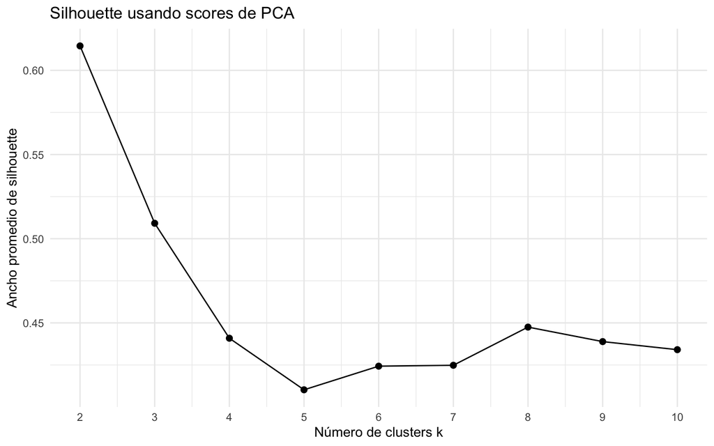

```r
set.seed(123)

sil_width_pca <- map_dbl(2:10, function(k) {
  km <- kmeans(pca_for_clustering, centers = k, nstart = 25)
  ss <- silhouette(km$cluster, dist(pca_for_clustering))
  mean(ss[, 3])
})

sil_pca_tbl <- tibble(
  k = 2:10,
  avg_silhouette_width = sil_width_pca
)

ggplot(sil_pca_tbl, aes(x = k, y = avg_silhouette_width)) +
  geom_line() +
  geom_point(size = 2) +
  scale_x_continuous(breaks = 2:10) +
  theme_minimal() +
  labs(
    title = "Silhouette usando scores de PCA",
    x = "Número de clusters k",
    y = "Ancho promedio de silhouette"
  )
```

```r
sil_pca_tbl %>%
  arrange(desc(avg_silhouette_width))
```

| k | avg_silhouette_width |
| --- | --- |
| 2 | 0.6145202 |
| 3 | 0.5091683 |
| 8 | 0.4475094 |
| 4 | 0.4408934 |
| 9 | 0.4388894 |
| 10 | 0.4340904 |
| 7 | 0.4248250 |
| 6 | 0.4242959 |
| 5 | 0.4102606 |

## 11.6 K-means sobre scores de PCA

Para mantener la comparación con las tres especies conocidas, usaremos `k = 3`.

```r
set.seed(123)

km_pca_final <- kmeans(
  x = pca_for_clustering,
  centers = 3,
  nstart = 50
)

iris_pca_clustered <- iris_tbl %>%
  mutate(cluster_pca = factor(km_pca_final$cluster))

iris_pca_clustered %>%
  count(cluster_pca)
```

| cluster_pca | n |
| --- | --- |
| 1 | 50 |
| 2 | 47 |
| 3 | 53 |

Visualizamos los clusters en el espacio PCA.

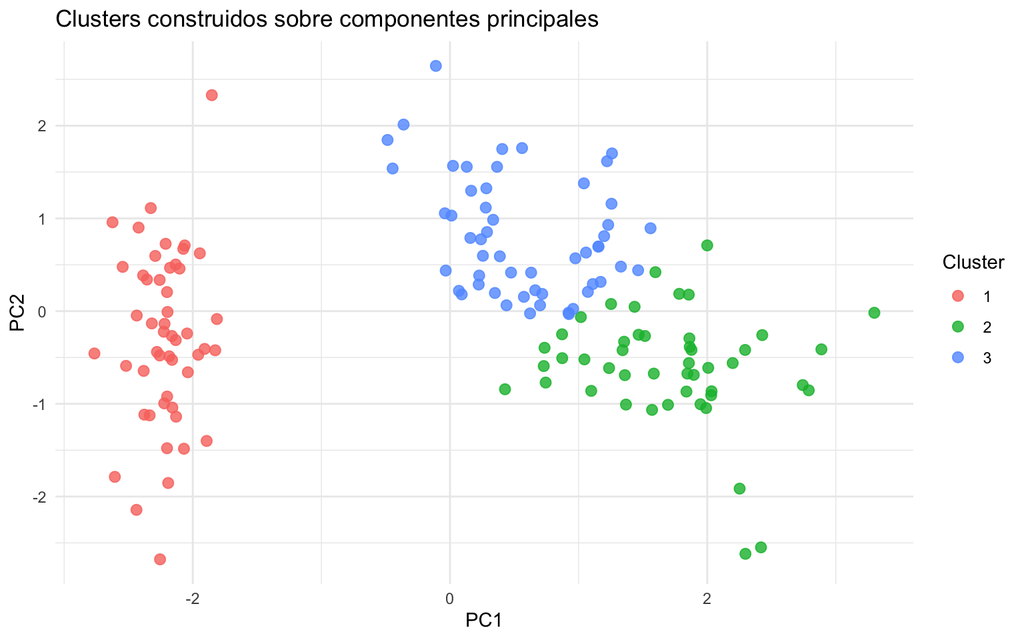

```r
pca_cluster_plot_data <- pca_scores %>%
  mutate(cluster_pca = iris_pca_clustered$cluster_pca)

ggplot(pca_cluster_plot_data, aes(x = PC1, y = PC2, color = cluster_pca)) +
  geom_point(size = 2.5, alpha = 0.8) +
  theme_minimal() +
  labs(
    title = "Clusters construidos sobre componentes principales",
    x = "PC1",
    y = "PC2",
    color = "Cluster"
  )
```

Comparamos los clusters basados en PCA con la especie conocida.

```r
table(
  Cluster = iris_pca_clustered$cluster_pca,
  Species = iris_pca_clustered$Species
)
```

```
##        Species
## Cluster setosa versicolor virginica
##       1     50          0         0
##       2      0         11        36
##       3      0         39        14
```

# 12. Perfilamiento de clusters

Después de crear clusters, el paso más importante es interpretarlos. Para esto calculamos resúmenes descriptivos por cluster.

```r
cluster_profile <- iris_pca_clustered %>%
  group_by(cluster_pca) %>%
  summarise(
    n = n(),
    across(
      .cols = Sepal.Length:Petal.Width,
      .fns = list(
        mean = mean,
        sd = sd,
        median = median
      ),
      .names = "{.col}_{.fn}"
    ),
    .groups = "drop"
  )

cluster_profile
```

| cluster_pca | n | Sepal.Length_mean | Sepal.Length_sd | Sepal.Length_median | Sepal.Width_mean | Sepal.Width_sd | Sepal.Width_median | Petal.Length_mean | Petal.Length_sd | Petal.Length_median | Petal.Width_mean | Petal.Width_sd | Petal.Width_median |
| --- | --- | --- | --- | --- | --- | --- | --- | --- | --- | --- | --- | --- | --- |
| 1 | 50 | 5.006000 | 0.3524897 | 5.0 | 3.428000 | 0.3790644 | 3.4 | 1.462000 | 0.1736640 | 1.5 | 0.246000 | 0.1053856 | 0.2 |
| 2 | 47 | 6.780851 | 0.4906244 | 6.7 | 3.095745 | 0.2620633 | 3.1 | 5.510638 | 0.6380112 | 5.6 | 1.972340 | 0.3308107 | 2.0 |
| 3 | 53 | 5.801887 | 0.4054867 | 5.8 | 2.673585 | 0.2543097 | 2.7 | 4.369811 | 0.5604205 | 4.4 | 1.413208 | 0.3113480 | 1.3 |

Una tabla puede ser útil, pero la visualización facilita la interpretación.

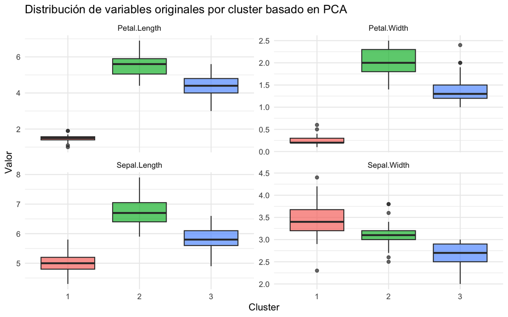

```r
iris_pca_clustered %>%
  pivot_longer(
    cols = Sepal.Length:Petal.Width,
    names_to = "variable",
    values_to = "valor"
  ) %>%
  ggplot(aes(x = cluster_pca, y = valor, fill = cluster_pca)) +
  geom_boxplot(alpha = 0.7) +
  facet_wrap(~ variable, scales = "free_y") +
  theme_minimal() +
  guides(fill = "none") +
  labs(
    title = "Distribución de variables originales por cluster basado en PCA",
    x = "Cluster",
    y = "Valor"
  )
```

# 13. Pruebas estadísticas entre clusters

Podemos evaluar si las variables difieren entre clusters.

Advertencia importante: si los clusters fueron construidos usando las mismas variables que luego se testean, los p-values deben interpretarse como **exploratorios o descriptivos**, no como evidencia confirmatoria estricta. El algoritmo fue diseñado para separar observaciones usando esas variables, por lo que diferencias significativas son esperables.

## 13.1 ANOVA entre clusters

ANOVA evalúa si la media de una variable numérica difiere entre varios grupos.

```r
cluster_test_data <- iris_tbl %>%
  mutate(cluster_pca = iris_pca_clustered$cluster_pca)

anova_results <- cluster_test_data %>%
  pivot_longer(
    cols = Sepal.Length:Petal.Width,
    names_to = "variable",
    values_to = "value"
  ) %>%
  group_by(variable) %>%
  summarise(
    p_value = summary(aov(value ~ cluster_pca))[[1]][["Pr(>F)"]][1],
    .groups = "drop"
  ) %>%
  mutate(p_adjusted = p.adjust(p_value, method = "BH"))

anova_results
```

| variable | p_value | p_adjusted |
| --- | --- | --- |
| Petal.Length | 7.029961e-82 | 2.811984e-81 |
| Petal.Width | 1.048715e-67 | 2.097429e-67 |
| Sepal.Length | 9.093246e-45 | 1.212433e-44 |
| Sepal.Width | 3.265505e-24 | 3.265505e-24 |

## 13.2 Tamaño de efecto para ANOVA

Un p-value muy pequeño no implica necesariamente un efecto grande. Podemos calcular eta cuadrado:

$$\eta^2 = \frac{SS_{\text{entre grupos}}}{SS_{\text{total}}}$$

```r
eta_squared_oneway <- function(data, response, group) {
  formula_obj <- as.formula(paste(response, "~", group))
  aov_obj <- aov(formula_obj, data = data)
  aov_tab <- summary(aov_obj)[[1]]

  ss_between <- aov_tab[1, "Sum Sq"]
  ss_total <- sum(aov_tab[, "Sum Sq"])

  ss_between / ss_total
}

eta_results <- tibble(
  variable = names(iris_num),
  eta_squared = map_dbl(
    variable,
    ~ eta_squared_oneway(cluster_test_data, .x, "cluster_pca")
  )
)

eta_results
```

| variable | eta_squared |
| --- | --- |
| Sepal.Length | 0.7483489 |
| Sepal.Width | 0.5208606 |
| Petal.Length | 0.9213177 |
| Petal.Width | 0.8773362 |

Interpretación general: valores más altos de `eta_squared` indican que una mayor proporción de la variación de la variable se explica por las diferencias entre clusters.

## 13.3 Pruebas post-hoc

Si ANOVA sugiere diferencias entre clusters, Tukey HSD permite identificar qué pares de clusters difieren.

```r
tukey_petal_length <- TukeyHSD(
  aov(Petal.Length ~ cluster_pca, data = cluster_test_data)
)

tukey_petal_length
```

```
##   Tukey multiple comparisons of means
##     95% family-wise confidence level
##
## Fit: aov(formula = Petal.Length ~ cluster_pca, data = cluster_test_data)
##
## $cluster_pca
##          diff       lwr        upr p adj
## 2-1  4.048638  3.808828  4.2884489     0
## 3-1  2.907811  2.675103  3.1405198     0
## 3-2 -1.140827 -1.377326 -0.9043278     0
```

Convertimos el resultado de Tukey a una tabla ordenada.

```r
broom::tidy(tukey_petal_length)
```

| term | contrast | null.value | estimate | conf.low | conf.high | adj.p.value |
| --- | --- | --- | --- | --- | --- | --- |
| cluster_pca | 2-1 | 0 | 4.048638 | 3.808828 | 4.2884489 | 2.997602e-15 |
| cluster_pca | 3-1 | 0 | 2.907811 | 2.675103 | 3.1405198 | 2.997602e-15 |
| cluster_pca | 3-2 | 0 | -1.140827 | -1.377326 | -0.9043278 | 1.254552e-14 |

## 13.4 Alternativa no paramétrica: Kruskal-Wallis

Si los supuestos de normalidad u homogeneidad de varianzas no son razonables, Kruskal-Wallis puede usarse como alternativa no paramétrica.

```r
kruskal_results <- cluster_test_data %>%
  pivot_longer(
    cols = Sepal.Length:Petal.Width,
    names_to = "variable",
    values_to = "value"
  ) %>%
  group_by(variable) %>%
  summarise(
    p_value = kruskal.test(value ~ cluster_pca)$p.value,
    .groups = "drop"
  ) %>%
  mutate(p_adjusted = p.adjust(p_value, method = "BH"))

kruskal_results
```

| variable | p_value | p_adjusted |
| --- | --- | --- |
| Petal.Length | 3.821315e-27 | 1.528526e-26 |
| Petal.Width | 8.283637e-27 | 1.656727e-26 |
| Sepal.Length | 5.678465e-26 | 7.571287e-26 |
| Sepal.Width | 4.197689e-20 | 4.197689e-20 |

Para comparaciones post-hoc no paramétricas se pueden usar pruebas de Wilcoxon por pares.

```r
pairwise.wilcox.test(
  x = cluster_test_data$Petal.Length,
  g = cluster_test_data$cluster_pca,
  p.adjust.method = "BH"
)
```

```
##
##  Pairwise comparisons using Wilcoxon rank sum test with continuity correction
##
## data:  cluster_test_data$Petal.Length and cluster_test_data$cluster_pca
##
##   1      2
## 2 <2e-16 -
## 3 <2e-16 2e-12
##
## P value adjustment method: BH
```

## 13.5 Validación externa con una variable categórica

Como `iris` tiene una etiqueta conocida de especie, podemos evaluar si la membresía al cluster está asociada con la especie.

```r
cluster_species_table <- table(
  Cluster = cluster_test_data$cluster_pca,
  Species = cluster_test_data$Species
)

cluster_species_table
```

```
##        Species
## Cluster setosa versicolor virginica
##       1     50          0         0
##       2      0         11        36
##       3      0         39        14
```

```r
chisq.test(cluster_species_table)
```

```
##
##  Pearson's Chi-squared test
##
## data:  cluster_species_table
## X-squared = 187.64, df = 4, p-value < 2.2e-16
```

Interpretación: esta prueba evalúa si la distribución de especies difiere entre clusters. En datasets sin etiquetas conocidas, este paso no está disponible.

# 14. Regresión para predecir membresía a clusters

Una vez definidos los clusters, podemos entrenar un modelo supervisado para predecir la asignación de cluster en nuevas observaciones.

Esto puede ser útil cuando:

1. El procedimiento de clustering es costoso o complejo.
2. Queremos una aproximación predictiva simple de los grupos encontrados.
3. Queremos entender qué variables ayudan a clasificar observaciones en clusters.

Nota: el modelo de regresión predice las etiquetas creadas por el algoritmo de clustering. Esto no demuestra que los clusters sean biológica, clínica o comercialmente reales.

## 14.1 Preparar conjuntos de entrenamiento y prueba

Predeciremos la membresía al cluster basado en PCA usando las cuatro variables originales.

```r
set.seed(123)

model_data <- iris_tbl %>%
  mutate(cluster_pca = iris_pca_clustered$cluster_pca) %>%
  select(cluster_pca, Sepal.Length, Sepal.Width, Petal.Length, Petal.Width)

train_index <- sample(seq_len(nrow(model_data)), size = 0.70 * nrow(model_data))

train_data <- model_data[train_index, ]
test_data  <- model_data[-train_index, ]

train_data %>% count(cluster_pca)
```

| cluster_pca | n |
| --- | --- |
| 1 | 36 |
| 2 | 32 |
| 3 | 37 |

```r
test_data %>% count(cluster_pca)
```

| cluster_pca | n |
| --- | --- |
| 1 | 14 |
| 2 | 15 |
| 3 | 16 |

## 14.2 Regresión logística multinomial

Como la variable respuesta tiene más de dos clases, usamos regresión logística multinomial.

```r
multinom_model <- multinom(
  cluster_pca ~ Sepal.Length + Sepal.Width + Petal.Length + Petal.Width,
  data = train_data,
  trace = FALSE
)

summary(multinom_model)
```

```
## Call:
## multinom(formula = cluster_pca ~ Sepal.Length + Sepal.Width +
##     Petal.Length + Petal.Width, data = train_data, trace = FALSE)
##
## Coefficients:
##   (Intercept) Sepal.Length Sepal.Width Petal.Length Petal.Width
## 2   -353.5206    -16.12549    43.45049     69.52301   26.127693
## 3    297.1116    -70.98596   -27.04453     57.83620   -1.939747
##
## Std. Errors:
##   (Intercept) Sepal.Length Sepal.Width Petal.Length Petal.Width
## 2    315.6660     556.5236    1015.866     246.4098    190.0154
## 3    285.1256     559.2522    1014.686     242.2525    188.0403
##
## Residual Deviance: 0.1774315
## AIC: 20.17743
```

## 14.3 Predecir clusters en el conjunto de prueba

```r
test_pred <- test_data %>%
  mutate(
    predicted_cluster = predict(multinom_model, newdata = test_data, type = "class")
  )

head(test_pred)
```

| cluster_pca | Sepal.Length | Sepal.Width | Petal.Length | Petal.Width | predicted_cluster |
| --- | --- | --- | --- | --- | --- |
| 1 | 5.1 | 3.5 | 1.4 | 0.2 | 1 |
| 1 | 4.9 | 3.0 | 1.4 | 0.2 | 1 |
| 1 | 4.7 | 3.2 | 1.3 | 0.2 | 1 |
| 1 | 5.0 | 3.6 | 1.4 | 0.2 | 1 |
| 1 | 5.4 | 3.7 | 1.5 | 0.2 | 1 |
| 1 | 5.1 | 3.5 | 1.4 | 0.3 | 1 |

## 14.4 Matriz de confusión y accuracy

```r
conf_mat <- table(
  Observado = test_pred$cluster_pca,
  Predicho = test_pred$predicted_cluster
)

conf_mat
```

```
##          Predicho
## Observado  1  2  3
##         1 14  0  0
##         2  0 15  0
##         3  0  1 15
```

```r
accuracy <- mean(test_pred$cluster_pca == test_pred$predicted_cluster)

accuracy
```

```
## [1] 0.9777778
```

## 14.5 Probabilidades de predicción

```r
pred_probs <- predict(multinom_model, newdata = test_data, type = "probs")

head(pred_probs)
```

```
##   1            2            3
## 1 1 2.177353e-79 4.955581e-35
## 2 1 2.011024e-87 5.413792e-23
## 3 1 2.875913e-85 1.092475e-21
## 4 1 8.419400e-77 4.012794e-33
## 5 1 1.072439e-74 4.066190e-44
## 6 1 2.969205e-78 4.081807e-35
```

Agregamos la probabilidad máxima predicha al conjunto de prueba. Esto puede interpretarse como una medida de confianza del modelo.

```r
test_pred_with_confidence <- test_pred %>%
  mutate(max_probability = apply(pred_probs, 1, max))

test_pred_with_confidence %>%
  arrange(max_probability) %>%
  head(10)
```

| cluster_pca | Sepal.Length | Sepal.Width | Petal.Length | Petal.Width | predicted_cluster | max_probability |
| --- | --- | --- | --- | --- | --- | --- |
| 3 | 6.5 | 2.8 | 4.6 | 1.5 | 3 | 0.6883826 |
| 3 | 6.6 | 2.9 | 4.6 | 1.3 | 2 | 0.9978270 |
| 2 | 6.8 | 2.8 | 4.8 | 1.4 | 2 | 0.9999997 |
| 2 | 6.3 | 2.9 | 5.6 | 1.8 | 2 | 0.9999998 |
| 2 | 6.7 | 3.1 | 4.4 | 1.4 | 2 | 0.9999998 |
| 3 | 6.2 | 2.9 | 4.3 | 1.3 | 3 | 1.0000000 |
| 3 | 5.9 | 3.0 | 4.2 | 1.5 | 3 | 1.0000000 |
| 2 | 6.4 | 2.8 | 5.6 | 2.2 | 2 | 1.0000000 |
| 3 | 6.0 | 2.7 | 5.1 | 1.6 | 3 | 1.0000000 |
| 3 | 5.6 | 2.9 | 3.6 | 1.3 | 3 | 1.0000000 |

Las observaciones con menor probabilidad máxima son aquellas donde el modelo está más inseguro.

## 14.6 Regresión logística uno-contra-el-resto

Una interpretación más simple puede obtenerse modelando la probabilidad de pertenecer a un cluster específico versus todos los demás.

Aquí modelaremos la membresía al cluster 1.

```r
binary_data <- model_data %>%
  mutate(is_cluster_1 = if_else(cluster_pca == "1", 1, 0))

binary_model <- glm(
  is_cluster_1 ~ Sepal.Length + Sepal.Width + Petal.Length + Petal.Width,
  data = binary_data,
  family = binomial()
)

summary(binary_model)
```

```
##
## Call:
## glm(formula = is_cluster_1 ~ Sepal.Length + Sepal.Width + Petal.Length +
##     Petal.Width, family = binomial(), data = binary_data)
##
## Coefficients:
##                Estimate Std. Error z value Pr(>|z|)
## (Intercept)     -16.946 457457.097       0        1
## Sepal.Length     11.759 130504.042       0        1
## Sepal.Width       7.842  59415.385       0        1
## Petal.Length    -20.088 107724.594       0        1
## Petal.Width     -21.608 154350.616       0        1
##
## (Dispersion parameter for binomial family taken to be 1)
##
##     Null deviance: 1.9095e+02  on 149  degrees of freedom
## Residual deviance: 3.2940e-09  on 145  degrees of freedom
## AIC: 10
##
## Number of Fisher Scoring iterations: 25
```

# 15. Resumen del flujo completo

El flujo completo fue:

1. Seleccionar variables numéricas.
2. Escalar las variables.
3. Explorar clustering con k-means y clustering jerárquico.
4. Elegir el número de clusters usando codo, silhouette y gap statistic.
5. Ejecutar PCA.
6. Crear clusters usando componentes principales seleccionadas.
7. Perfilar e interpretar los clusters.
8. Comparar estadísticamente las variables entre clusters.
9. Usar regresión logística multinomial para predecir la membresía a cluster.

# 16. Ejercicios

## Ejercicio 1: Comparar k-means y clustering jerárquico

Usando las variables escaladas de `iris`:

1. Ejecuta k-means con `k = 2`, `k = 3` y `k = 4`.
2. Compara el ancho promedio de silhouette.
3. ¿Qué valor de `k` elegirías? Justifica tu respuesta.

## Ejercicio 2: Clustering basado en PCA

1. Ejecuta PCA sobre las variables escaladas de `iris`.
2. Conserva solo las dos primeras componentes principales.
3. Ejecuta k-means con `k = 3` sobre esas dos componentes.
4. Compara esa solución con el clustering usando suficientes componentes para explicar al menos 90% de la varianza.

## Ejercicio 3: Interpretación estadística

Usando los clusters basados en PCA:

1. Compara `Sepal.Length`, `Sepal.Width`, `Petal.Length` y `Petal.Width` entre clusters usando ANOVA.
2. Repite usando Kruskal-Wallis.
3. ¿Las conclusiones son similares?
4. ¿Por qué los p-values deben interpretarse con cuidado después de hacer clustering?

## Ejercicio 4: Predecir membresía a cluster

1. Entrena un modelo de regresión logística multinomial para predecir las etiquetas de cluster.
2. Divide los datos en 70% entrenamiento y 30% prueba.
3. Reporta la matriz de confusión y el accuracy.
4. ¿Qué variables parecen más útiles para la predicción?

## Ejercicio 5: Aplicar el flujo a otro dataset

Repite el flujo completo usando `USArrests`.

Pistas:

```r
data("USArrests")

usarrests_tbl <- as_tibble(USArrests, rownames = "State")

usarrests_num <- USArrests

usarrests_scaled <- scale(usarrests_num)
```

Preguntas:

1. ¿Cuál parece ser el número óptimo de clusters?
2. ¿Qué representan los clusters?
3. ¿Qué variables difieren más entre clusters?
4. ¿Puedes predecir la membresía a cluster usando regresión logística multinomial?

# 17. Ejercicios avanzados

## Estabilidad de clusters mediante bootstrap

Una debilidad del clustering es que los resultados pueden ser inestables. Un análisis más avanzado consiste en repetir el clustering muchas veces usando muestras bootstrap y evaluar si grupos similares aparecen de forma repetida.

Algunos paquetes útiles para evaluar estabilidad de clusters son:

- `fpc`
- `clValid`
- `mclust`

En este notebook introductorio no los usaremos para evitar agregar complejidad, pero son útiles para proyectos más avanzados.

# 18. Notas finales

Un buen análisis de clustering no consiste solo en correr un algoritmo. Un análisis sólido debería responder:

1. ¿Los clusters son visual y estadísticamente coherentes?
2. ¿Los clusters son estables?
3. ¿Son interpretables?
4. ¿Son útiles para predicción o toma de decisiones?
5. ¿Tienen sentido en el contexto científico, clínico o de negocio?